# The impact of gender on the prevalence and patterns of drunk driving among individuals who consume alcohol.

Anamarys Arroyo-Lloret

Fall 2023

## Introduction

For this final project, my research question centers around exploring the impact of gender on the prevalence and patterns of drunk driving among individuals who consume alcohol. According to the National Highway Traffic Safety Administration (NHTSA), research shows that in the United States, approximately 37 people die each day due to driving while intoxicated. Additionally, about 31% of car crash deaths in the United States involve drunk drivers (NHTSA, n.d.). Studies from previous experiments show that alcohol impairs both men and women significantly, but women show greater impairment than men (Miller et al., 2009). Furthermore, men are more likely to be current drinkers and to engage in heavy drinking compared to women (Wilsnack et al., 2009). Schwartz & Beltz (2018) found that male intoxicated drivers outdo female rates; however, female rates of intoxicated drivers are on the rise. I will be using data from the National Survey on Drug Use and Health (NSDUH) from 1996. The NSDUH is a series of surveys conducted to measure prevalence and correlated of substance abuse in the United States. The population is individuals over the age of 12, active-duty military, and individuals that are homeless in the United States. The NSDUH covers substance use, mental health, alcohol, tobacco, and other health issues. The variables in the dataset are of the types categorical and continuous. The units used for measurement are length in inches, weight in pounds, and counts.  
I began manipulating the data by creating a smaller subset (DrugData2) and exporting it for analysis. Missing codes in alcohol and drunk driving-related variables were addressed by replacing them with NA and replacing certain codes like “did not drive drunk” or “did not use alcohol in the past 30 days” to 0. Additionally, the dataset was segmented into alcohol users and non-alcohol users based on drink counts, and a new categorical variable categorizing drinkers into three categories was created based on the number of drinks consumed.

## Data Exploration and Visualization

**Days Driven Drunk in the Past 30 Days by Sex**

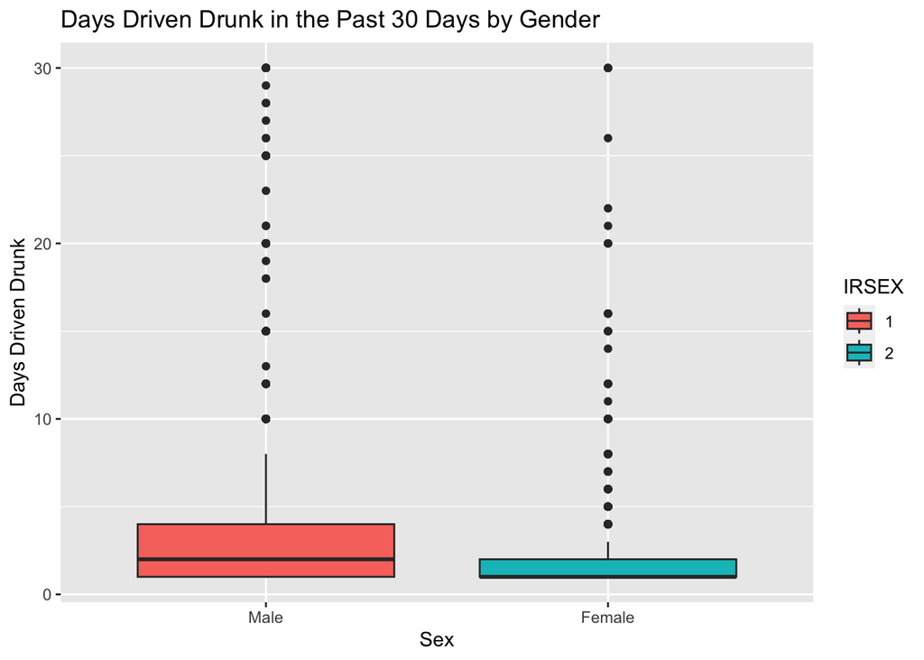

**Distribution of Days Driven Drunk by Sex**

The chart was made using ggplot, showcasing the number of days individuals drove drunk in the past year grouped by gender. It involved arranging bars using geom_bar() to display the distribution, with different colors representing males and females.

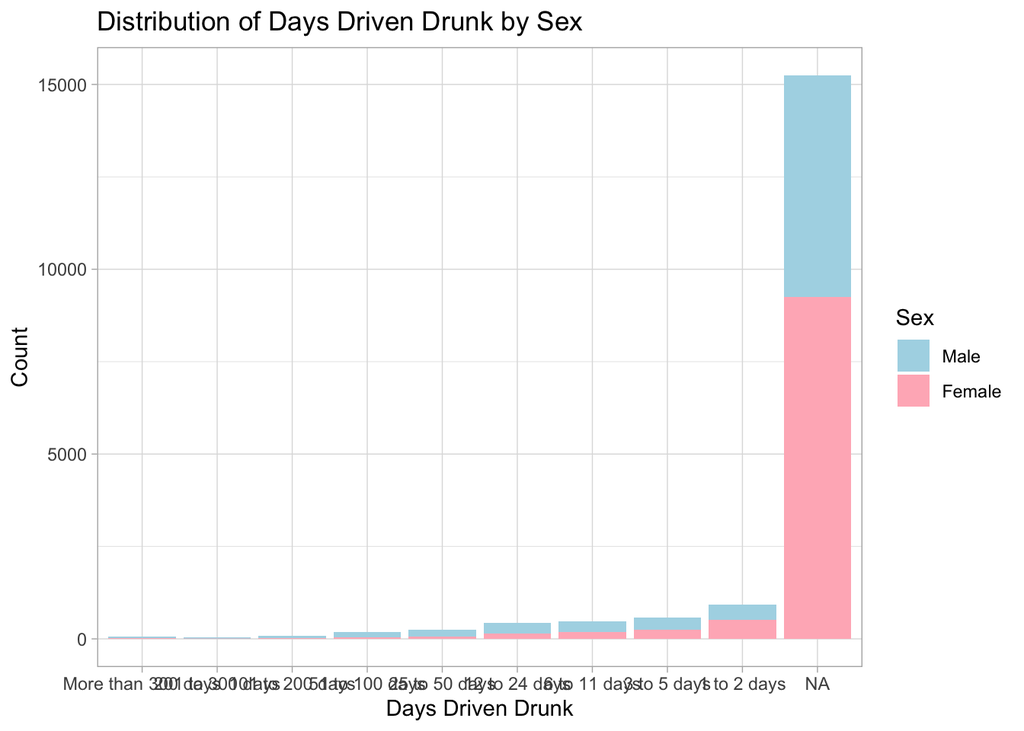

### Descriptive Statistics

**Psychometric Analysis**

```
##           vars     n   mean    sd median trimmed   mad min max range  skew
## IRAGE        1 18269  28.29 13.68     26   26.40 11.86  12  94    82  1.41
## IRSEX*       2 18269   1.57  0.49      2    1.59  0.00   1   2     1 -0.30
## IRRACE       3 18269   3.64  0.62      4    3.75  0.00   1   4     3 -1.94
## IREDUC       4 18269  11.36  3.26     12   11.47  2.97   0  17    17 -0.35
## IRALCFQ      5 18269   7.56  2.65      8    7.90  2.97   1  10     9 -0.75
## CIGFLAG      6 18269   0.60  0.49      1    0.63  0.00   0   1     1 -0.42
## ALCFLAG      7 18269   0.72  0.45      1    0.78  0.00   0   1     1 -0.99
## WORKSTAT     8 18238   4.25  3.79      2    3.93  1.48   1  32    31  1.85
## HTININCH     9 18144  65.97  4.23     66   65.91  4.45  36 104    68 -0.03
## POUNDS      10 18020 156.15 39.86    150  152.94 37.06  55 550   495  0.97
## HEALTH      11 18235   2.08  1.00      2    1.97  1.48   1   5     4  0.66
## DRUNKYR     12  5207   6.97  2.06      8    7.24  1.48   1   9     8 -0.91
## ALCTRY      13 13062  16.55  4.23     16   16.38  2.97   2  59    57  1.42
## CIGTRY      14 10932  15.14  4.29     15   14.91  2.97   2  70    68  1.38
## VALYRFRQ*   15  3021   7.02  1.98      7    7.30  2.97   1   9     8 -1.00
## VAL30USE    16  1884   3.54  4.85      2    2.33  1.48   1  30    29  3.38
## NODR30A     17  7700   3.28  3.33      2    2.66  1.48   1  50    49  4.52
## category*   18  7700   1.59  0.72      1    1.49  0.00   1   3     2  0.80
##           kurtosis   se
## IRAGE         2.45 0.10
## IRSEX*       -1.91 0.00
## IRRACE        4.20 0.00
## IREDUC       -0.12 0.02
## IRALCFQ      -0.63 0.02
## CIGFLAG      -1.83 0.00
## ALCFLAG      -1.02 0.00
## WORKSTAT      9.13 0.03
## HTININCH      1.25 0.03
## POUNDS        2.16 0.30
## HEALTH       -0.22 0.01
## DRUNKYR       0.01 0.03
## ALCTRY        8.96 0.04
## CIGTRY        7.91 0.04
## VALYRFRQ*     0.46 0.04
## VAL30USE     12.59 0.11
## NODR30A      34.70 0.04
## category*    -0.69 0.01
```

**Relationship Between Age and Drunk Driving Frequency: Correlation Matrix Analysis**

I analyzed the correlation coefficient between the number of days driven drunk within the last 30 days and age. There was weak correlation, showing very little association.

```
##            VAL30USE      IRAGE
## VAL30USE 1.00000000 0.02106015
## IRAGE    0.02106015 1.00000000
```

**Demographics and Alcohol Use: Contingency Analysis**

```
##                  IRRACE American Indian or Alaskan Native Asian Black White
## ALCFLAG    IRSEX
## Ever Used  1                                          113   147  1218  4343
##            2                                          106   130  1893  5237
## Never Used 1                                           31    99   560  1263
##            2                                           48   123   953  2005
```

## Statistical analysis

### Linear Regression Analysis: Alcohol Consumption and Gender Across Drinking Levels

I developed three linear models corresponding to light drinkers, moderate drinkers, and heavy drinkers. I decided on a segmented analysis approach. First, I segmented the variable NODR30A into two groups: alcohol users and non-alcohol users. Then, within the alcohol user group, I further segmented the individuals into three drinking categories based on criteria from the National Institute on Alcohol Abuse and Alcoholism (light=0-2 drinks, moderate=2-5 drinks, heavy=5+ drinks). Age and sex were included as factors in the linear models. I had to code the sex variable as a factor to facilitate the analysis.

**Light Drinkers:**

The model revealed a statistically significant relationship between the number of drinks per day in a 30-day period and age and sex. It indicated that individuals of older age and females showed to have fewer alcoholic drinks compared to men. However, the model only explained a small portion of the variance (Adjusted R-Squared = 0.01163), which suggests that there might be other outside factors influencing this relationship.

```
##
## Call:
## lm(formula = NODR30A ~ IRAGE + IRSEX, data = light)
##
## Residuals:
##     Min      1Q  Median      3Q     Max
## -0.6109 -0.4864 -0.3080  0.5051  0.6581
##
## Coefficients:
##               Estimate Std. Error t value Pr(>|t|)
## (Intercept)  1.6448488  0.0233153  70.548  < 2e-16 ***
## IRAGE       -0.0028322  0.0006085  -4.654 3.35e-06 ***
## IRSEX2      -0.0876649  0.0156693  -5.595 2.35e-08 ***
## ---
## Signif. codes:  0 '***' 0.001 '**' 0.01 '*' 0.05 '.' 0.1 ' ' 1
##
## Residual standard error: 0.4971 on 4236 degrees of freedom
## Multiple R-squared:  0.01209,    Adjusted R-squared:  0.01163
## F-statistic: 25.93 on 2 and 4236 DF,  p-value: 6.422e-12
```

**Moderate Drinkers:**

Results for the moderate drinkers group were similar to that of the light drinkers. Older individuals and females showed less alcoholic drink consumption compared to men. Again, the Adjusted R-Squared (0.008077) suggests an external influence.

```
##
## Call:
## lm(formula = NODR30A ~ IRAGE + IRSEX, data = moderate)
##
## Residuals:
##     Min      1Q  Median      3Q     Max
## -0.9057 -0.7670  0.1290  0.5087  1.5789
##
## Coefficients:
##              Estimate Std. Error t value Pr(>|t|)
## (Intercept)  4.002793   0.054288  73.733  < 2e-16 ***
## IRAGE       -0.006935   0.001678  -4.133  3.7e-05 ***
## IRSEX2      -0.082395   0.033934  -2.428   0.0153 *
## ---
## Signif. codes:  0 '***' 0.001 '**' 0.01 '*' 0.05 '.' 0.1 ' ' 1
##
## Residual standard error: 0.8203 on 2379 degrees of freedom
## Multiple R-squared:  0.008911,   Adjusted R-squared:  0.008077
## F-statistic: 10.69 on 2 and 2379 DF,  p-value: 2.378e-05
```

**Heavy Drinkers:**

There was minimal association between age and heavy drinking. In terms of gender, females had fewer drinks per day compared to men. Again, the adjusted R-squared was low, measuring at 0.006285.

```
##
## Call:
## lm(formula = NODR30A ~ IRAGE + IRSEX, data = heavy)
##
## Residuals:
##    Min     1Q Median     3Q    Max
## -3.642 -3.314 -1.602  0.633 41.707
##
## Coefficients:
##             Estimate Std. Error t value Pr(>|t|)
## (Intercept)  9.81593    0.48662  20.172  < 2e-16 ***
## IRAGE       -0.01340    0.01678  -0.798  0.42481
## IRSEX2      -1.08057    0.37533  -2.879  0.00407 **
## ---
## Signif. codes:  0 '***' 0.001 '**' 0.01 '*' 0.05 '.' 0.1 ' ' 1
##
## Residual standard error: 5.358 on 1076 degrees of freedom
## Multiple R-squared:  0.008129,   Adjusted R-squared:  0.006285
## F-statistic: 4.409 on 2 and 1076 DF,  p-value: 0.01239
```

**Comparison of Gender Distribution Between Alcohol Users and Non-Alcohol Users**

I compared the proportion of males and females among alcohol users and non-alcohol users by categorizing the groups based on their alcohol use. I conducted the analysis using a table. Among alcohol users, females accounted for 51.04%, slightly higher than males at 48.96%. For non-alcohol users, females constituted 62.12% while males made up 37.88%. Non-alcohol users were more likely to be female compared to males. However, there wasn’t a significant difference observed among alcohol users.

```
##
##         1         2
## 0.4896104 0.5103896
```

```
##
##         1         2
## 0.3788438 0.6211562
```

## Conclusions

One of the main weaknesses lies in excluding those potentially influential variables related to drinking levels. Moreover, the dataset’s age, from 1996, presents a limitation since trends might differ. It would have been beneficial to include variables such as education, socioeconomic status, income, and other substance uses like cigarettes or drugs for a more comprehensive analysis.

## References

Miller, M. A., Weafer, J., & Fillmore, M. T. (2009). Gender Differences in Alcohol Impairment of Simulated Driving Performance and Driving-Related Skills. Alcohol & Alcoholism. 44(6), 586-593. doi: 10.1093/alcalc/agp051

National Highway Traffic Safety Administration (NHTSA). (n.d.). Drunk driving. https://www.nhtsa.gov/risky-driving/drunk-driving

National Institute on Alcohol Abuse and Alcoholism. (n.d.). Alcohol’s Effects on Health. Retrieved from https://www.niaaa.nih.gov/alcohol-health/overview-alcohol-consumption/moderate-binge-drinking

Schwartz, J., & Beltz, L. (2018). Trends in female and male drunken driving prevalence over thirty years: Triangulating diverse sources of evidence (1985–2015). Addictive Behaviors. 84, 7-12. https://doi.org/10.1016/j.addbeh.2018.03.024

Wilsnack, R. W., Wilsnack, S. C., Kristjanson, A. F., Vogeltanz-Holm, N. D., & Gmel, G. (2009). Gender and alcohol consumption: patterns from the multinational genacis project. Addiction. 104(9), 1487-1500. doi:10.1111/j.1360-0443.2009.02696.x.